Team Alpha (Group 3)\ BUDT758X-0501\ Youtube Trending Videos: Data Analysis\ Yudong Lu, Bethel Teshome, Eunisa Lu, Hui Chen, Makaela Jackson, Fengyi Zhao

Project data source:https://www.kaggle.com/datasnaek/youtube-new

# Project Report

## Introduction

YouTube's streaming platform displays a list of top trending videos which changes constantly based on a combination of various factors. Our project is meant to find patterns and relations between variables to draw conclusions and give suggestions to youtubers. Content creators with the goal of a trending video can find useful tips and suggestions based on our analysis of various YouTube metrics. The suggestions include the best topics and tags, publishing times, and metrics to increase their video popularity and success.

The questions we attempted to answer in our project were:\ How can youtubers tag their videos to improve their videos and what pattern they can learn from the tags from the trending video list?\ How can youtubers design the titles of video to attract more views and increase the chance of trending?\ When should a youtuber publish a video to get more views and get the videos trend faster?\ How impactful are user interactions on the success of videos?\ Which user interaction created the most trending videos? \ How does having comments disabled affect the views a video gets? How about having ratings disabled?\

For the first question, we believe that tags that are used in the videos can help youtubers to know what topic and types of video are more popular. We can provide suggestions to the youtubers from the tags analysis about their topic design and contents chosen for the video.

For our second question we wanted to know what aspects of a title would make a video more appealing and increase its popularity and likelihood of being on the top trending list. We will analyze our data to get the common length of the title, and also the popular words these trending videos will use to attract viewers.

For the third question, we have the assumption that publishing time would interfere with the speed of the video to get trending. To estimate at what period there are more audiences and at what time a video published will certainly have more viewers and trends faster than other videos.

For our fourth question we want to see the impact that each user interaction has on metrics used to measure a video's success such as engagement and impression. We also want to get a better understanding of the correlation between user interactions and how they play a role in whether a video makes the top trending list or not.

For our sixth question we wanted to know if disabling user interactions such as comments and ratings will positively or negatively affect the success of a video. Also if disabling these user interactions will lead to a positive or negative correlation with other user interactions such as views.

The answers to these questions matter because they can help content creators on YouTube use the algorithm that determines which videos make the top trending list to their advantage. This will increase the variety of content that is on the top trending list. As well as increase awareness of the video and the creators page which can increase monetization of their channel.

The dataset we analyzed is the daily record from the top 200 trending YouTube videos in the US region. The data was collected between November 14th, 2017 and June 14th, 2018 with missing dates of January 10-11th and April 7-13th of 2018. The dataset is from https://www.kaggle.com/datasnaek/youtube-new.

## Choice for Heavier Grading on Data Processing or Data Analysis

We choose to have heavier grading on the data analysis section because we believe that in this part, we demonstrate greater proficiency in a broader scope. We would like our project to be more heavily graded on data analysis because we believe our analyses regarding the variables that impact the success of a video goes above and beyond basic data analysis. Our data analysis seeks to understand the YouTube platform and trending algorithm from the perspective of the primary players, youtubers and users. In our data analysis we go in depth on how youtubers can be successful and have their videos put on the top trending list based on efforts on both sides. We have done deep analyses on each side and have created suggestions based on our findings.

Load required libraries

```python
import pandas as pd
import datetime as dt
import numpy as np
import re
import matplotlib.pyplot as plt
import seaborn as sns
import warnings
warnings.filterwarnings("ignore")
```

Import the data file and take a look at the first few rows and use .info to look at a summary of the dataframe

```python
df = pd.read_csv("USvideos.csv")
df.head()
```

|  | video_id | trending_date | title | channel_title | category_id | publish_time | tags | views | likes | dislikes | comment_count | thumbnail_link | comments_disabled | ratings_disabled | video_error_or_removed | description |
| --- | --- | --- | --- | --- | --- | --- | --- | --- | --- | --- | --- | --- | --- | --- | --- | --- |
| 0 | 2kyS6SvSYSE | 17.14.11 | WE WANT TO TALK ABOUT OUR MARRIAGE | CaseyNeistat | 22 | 2017-11-13T17:13:01.000Z | SHANtell martin | 748374 | 57527 | 2966 | 15954 | https://i.ytimg.com/vi/2kyS6SvSYSE/default.jpg | False | False | False | SHANTELL'S CHANNEL - https://www.youtube.com/s... |
| 1 | 1ZAPwfrtAFY | 17.14.11 | The Trump Presidency: Last Week Tonight with J... | LastWeekTonight | 24 | 2017-11-13T07:30:00.000Z | last week tonight trump presidency\|"last week ... | 2418783 | 97185 | 6146 | 12703 | https://i.ytimg.com/vi/1ZAPwfrtAFY/default.jpg | False | False | False | One year after the presidential election, John... |
| 2 | 5qpjK5DgCt4 | 17.14.11 | Racist Superman \| Rudy Mancuso, King Bach & Le... | Rudy Mancuso | 23 | 2017-11-12T19:05:24.000Z | racist superman\|"rudy"\|"mancuso"\|"king"\|"bach"... | 3191434 | 146033 | 5339 | 8181 | https://i.ytimg.com/vi/5qpjK5DgCt4/default.jpg | False | False | False | WATCH MY PREVIOUS VIDEO ▶ \n\nSUBSCRIBE ► http... |
| 3 | puqaWrEC7tY | 17.14.11 | Nickelback Lyrics: Real or Fake? | Good Mythical Morning | 24 | 2017-11-13T11:00:04.000Z | rhett and link\|"gmm"\|"good mythical morning"\|"... | 343168 | 10172 | 666 | 2146 | https://i.ytimg.com/vi/puqaWrEC7tY/default.jpg | False | False | False | Today we find out if Link is a Nickelback amat... |
| 4 | d380meD0W0M | 17.14.11 | I Dare You: GOING BALD!? | nigahiga | 24 | 2017-11-12T18:01:41.000Z | ryan\|"higa"\|"higatv"\|"nigahiga"\|"i dare you"\|"... | 2095731 | 132235 | 1989 | 17518 | https://i.ytimg.com/vi/d380meD0W0M/default.jpg | False | False | False | I know it's been a while since we did this sho... |

```python
df.info()
```

```
<class 'pandas.core.frame.DataFrame'>
RangeIndex: 40949 entries, 0 to 40948
Data columns (total 16 columns):
video_id                  40949 non-null object
trending_date             40949 non-null object
title                     40949 non-null object
channel_title             40949 non-null object
category_id               40949 non-null int64
publish_time              40949 non-null object
tags                      40949 non-null object
views                     40949 non-null int64
likes                     40949 non-null int64
dislikes                  40949 non-null int64
comment_count             40949 non-null int64
thumbnail_link            40949 non-null object
comments_disabled         40949 non-null bool
ratings_disabled          40949 non-null bool
video_error_or_removed    40949 non-null bool
description               40379 non-null object
dtypes: bool(3), int64(5), object(8)
memory usage: 4.2+ MB
```

## Data Processing

Some of the datas such as 'views', 'likes', 'dislikes', 'comment_count' are well formarted and we can use them directly in future analysis. Other columns must be cleaned accordingly

One of our research questions uses the publish time of videos column which was not properly formatted. To fix it, we converted the values in 'publish_time' into a datetime object in the form of 'year-month-day hour:minute:second' and split it up into two new columns, 'publish_date' and 'publish_time'. We applied this same process to 'trending_date'.

```python
df["publish_time"]=pd.to_datetime(df['publish_time'], format='%Y-%m-%dT%H:%M:%S.000Z')
df["publish_date"]=pd.to_datetime(df['publish_time']).dt.date
df['publish_time2']=pd.to_datetime(df['publish_time']).dt.time
df["trending_date"]=pd.to_datetime(df['trending_date'], format='%y.%d.%m')
df.head()
```

|  | video_id | trending_date | title | channel_title | category_id | publish_time | tags | views | likes | dislikes | comment_count | thumbnail_link | comments_disabled | ratings_disabled | video_error_or_removed | description | publish_date | publish_time2 |
| --- | --- | --- | --- | --- | --- | --- | --- | --- | --- | --- | --- | --- | --- | --- | --- | --- | --- | --- |
| 0 | 2kyS6SvSYSE | 2017-11-14 | WE WANT TO TALK ABOUT OUR MARRIAGE | CaseyNeistat | 22 | 2017-11-13 17:13:01 | SHANtell martin | 748374 | 57527 | 2966 | 15954 | https://i.ytimg.com/vi/2kyS6SvSYSE/default.jpg | False | False | False | SHANTELL'S CHANNEL - https://www.youtube.com/s... | 2017-11-13 | 17:13:01 |
| 1 | 1ZAPwfrtAFY | 2017-11-14 | The Trump Presidency: Last Week Tonight with J... | LastWeekTonight | 24 | 2017-11-13 07:30:00 | last week tonight trump presidency\|"last week ... | 2418783 | 97185 | 6146 | 12703 | https://i.ytimg.com/vi/1ZAPwfrtAFY/default.jpg | False | False | False | One year after the presidential election, John... | 2017-11-13 | 07:30:00 |
| 2 | 5qpjK5DgCt4 | 2017-11-14 | Racist Superman \| Rudy Mancuso, King Bach & Le... | Rudy Mancuso | 23 | 2017-11-12 19:05:24 | racist superman\|"rudy"\|"mancuso"\|"king"\|"bach"... | 3191434 | 146033 | 5339 | 8181 | https://i.ytimg.com/vi/5qpjK5DgCt4/default.jpg | False | False | False | WATCH MY PREVIOUS VIDEO ▶ \n\nSUBSCRIBE ► http... | 2017-11-12 | 19:05:24 |
| 3 | puqaWrEC7tY | 2017-11-14 | Nickelback Lyrics: Real or Fake? | Good Mythical Morning | 24 | 2017-11-13 11:00:04 | rhett and link\|"gmm"\|"good mythical morning"\|"... | 343168 | 10172 | 666 | 2146 | https://i.ytimg.com/vi/puqaWrEC7tY/default.jpg | False | False | False | Today we find out if Link is a Nickelback amat... | 2017-11-13 | 11:00:04 |
| 4 | d380meD0W0M | 2017-11-14 | I Dare You: GOING BALD!? | nigahiga | 24 | 2017-11-12 18:01:41 | ryan\|"higa"\|"higatv"\|"nigahiga"\|"i dare you"\|"... | 2095731 | 132235 | 1989 | 17518 | https://i.ytimg.com/vi/d380meD0W0M/default.jpg | False | False | False | I know it's been a while since we did this sho... | 2017-11-12 | 18:01:41 |

Using the 'publish_time' column, we generated the weekday each video was published and put them in a new column named 'publish_weekday'. 0-6 in publish_weekday represents from Monday to Sunday respectively.

```python
df['publish_weekday']=pd.to_datetime(df['publish_time']).dt.weekday
print(df['publish_weekday'])
df[['title','publish_weekday']].groupby('publish_weekday').count()
```

```
0        0
1        0
2        6
3        0
4        6
        ..
40944    4
40945    4
40946    4
40947    3
40948    3
Name: publish_weekday, Length: 40949, dtype: int64
```

| publish_weekday | title |
| --- | --- |
| 0 | 6177 |
| 1 | 6786 |
| 2 | 6762 |
| 3 | 6950 |
| 4 | 7002 |
| 5 | 3593 |
| 6 | 3679 |

We then found the difference between trending date and publishing time and stored the vallues in a new clolumn named 'time_to_trend'. Using this column, we can find how fast each video trends after publishing.

```python
df['time_to_trend']=df["trending_date"]-df["publish_time"]
df['days_to_trend']=df['time_to_trend'].dt.days
print(df['days_to_trend'])
df[['title','days_to_trend']].groupby('days_to_trend').count().head(10)
```

```
0         0
1         0
2         1
3         0
4         1
         ..
40944    26
40945    26
40946    26
40947    27
40948    27
Name: days_to_trend, Length: 40949, dtype: int64
```

| days_to_trend | title |
| --- | --- |
| -1 | 120 |
| 0 | 2843 |
| 1 | 4304 |
| 2 | 4642 |
| 3 | 4694 |
| 4 | 4586 |
| 5 | 4038 |
| 6 | 3127 |
| 7 | 2184 |
| 8 | 1658 |

Next, we used bins by binning publishing time into four periods of time (midnight to 6 being night, 6am-12pm being morning, 12pm-18pm being afternoon, and 18pm to midnight being evening) and identifying them as night, morning, afternoon and evening. By doing so, we give more meaning to publishing time so that we can use more statistical approaches on the data.

```python
bins=[0,6,12,18,24]
label=['Night','Morning','Afternoon','Evening']
df['time_bin'] = pd.cut(df['publish_time'].dt.hour, bins,labels=label)
print(df['time_bin'])
df[['title','time_bin']].groupby('time_bin').count()
```

```
0        Afternoon
1          Morning
2          Evening
3          Morning
4        Afternoon
           ...
40944    Afternoon
40945        Night
40946    Afternoon
40947    Afternoon
40948    Afternoon
Name: time_bin, Length: 40949, dtype: category
Categories (4, object): [Night < Morning < Afternoon < Evening]
```

| time_bin | title |
| --- | --- |
| Night | 6244 |
| Morning | 5043 |
| Afternoon | 18400 |
| Evening | 9826 |

'Tags' is the most informative and extensive part of the dateset. It represents the keywords and tags that each trending Youtube video is identified by in their search algorithm. To process the data, we first wipe off unnecessary punctuations to make the tags more easy to read. Then we create a list of all tags and count them, forming a result that includes all tags by all videos.

Since we already have the list of all tags, we can get the top 20 tags that have the largest frequencies. This shows the structure of what we can do on the tags with further conditions on other variables in the final report, such as given months, channel, category etc.

```python
df['tags']=df['tags'].str.replace('\"|\[none\]','')
all_tags=[]
for i in range(df.shape[0]):
    all_tags=all_tags+df['tags'][i].split("|")
```

```python
tags_result=pd.Series(all_tags).value_counts()
tags_result.head(20)
```

```
funny        3603
comedy       2931
how to       1604
             1549
music        1302
Pop          1280
2018         1275
humor        1185
food         1159
science      1111
review       1005
makeup        990
news          988
celebrity     930
vlog          928
video         890
tutorial      864
live          862
comedian      861
interview     845
dtype: int64
```

Get overall information for the quantitative variables using .describe()

```python
stats=df[['views','likes','dislikes','comment_count']]
stats.describe()
```

|  | views | likes | dislikes | comment_count |
| --- | --- | --- | --- | --- |
| count | 4.094900e+04 | 4.094900e+04 | 4.094900e+04 | 4.094900e+04 |
| mean | 2.360785e+06 | 7.426670e+04 | 3.711401e+03 | 8.446804e+03 |
| std | 7.394114e+06 | 2.288853e+05 | 2.902971e+04 | 3.743049e+04 |
| min | 5.490000e+02 | 0.000000e+00 | 0.000000e+00 | 0.000000e+00 |
| 25% | 2.423290e+05 | 5.424000e+03 | 2.020000e+02 | 6.140000e+02 |
| 50% | 6.818610e+05 | 1.809100e+04 | 6.310000e+02 | 1.856000e+03 |
| 75% | 1.823157e+06 | 5.541700e+04 | 1.938000e+03 | 5.755000e+03 |
| max | 2.252119e+08 | 5.613827e+06 | 1.674420e+06 | 1.361580e+06 |

We design a new variable called 'Impressions', which is the sum of views, likes, dislikes and comment_count.

```python
#Column for Impressions gotten by the videos
df['Impressions'] = df['views'] + df['likes'] + df['dislikes'] + df['comment_count']
df['Impressions'].describe()
```

```
count    4.094900e+04
mean     2.447210e+06
std      7.626773e+06
min      5.630000e+02
25%      2.534190e+05
50%      7.084400e+05
75%      1.897485e+06
max      2.310961e+08
Name: Impressions, dtype: float64
```

We design a new variable called 'Engagement', which is the sum of likes, dislikes and comment_count.

```python
#Column for total engagements gotten from video
df['Engagement'] = df['likes'] + df['dislikes'] + df['comment_count']
df['Engagement'].describe()
```

```
count    4.094900e+04
mean     8.642491e+04
std      2.754207e+05
min      0.000000e+00
25%      6.775000e+03
50%      2.149200e+04
75%      6.393900e+04
max      7.049374e+06
Name: Engagement, dtype: float64
```

We deisgn a new variable called 'rating', which is the likes minus dislike over the sum of likes and dislike

```python
df['rating'] = (df['likes'] - df['dislikes'])/(df['likes'] + df['dislikes'])
df['rating'].describe()
```

```
count    40779.000000
mean         0.866225
std          0.204633
min         -1.000000
25%          0.860663
50%          0.933975
75%          0.965580
max          1.000000
Name: rating, dtype: float64
```

The statistics are distributed expontentially distributed, but we need to normalize it for analysis

```python
df['views_log']=np.log(df['views'])
df['likes_log']=np.log(df['likes'])
df['dislikes_log']=np.log(df['dislikes'])
df['comment_count_log']=np.log(df['comment_count'])
df['Impressions_log']=np.log(df['Impressions'])
df['Engagement_log']=np.log(df['Engagement'])
```

Overview of all quantitative variables

```python
stats=df[['views_log','likes_log','dislikes_log','comment_count_log','Impressions_log','Engagement_log','rating']]
stats.describe()
```

|  | views_log | likes_log | dislikes_log | comment_count_log | Impressions_log | Engagement_log | rating |
| --- | --- | --- | --- | --- | --- | --- | --- |
| count | 40949.000000 | 4.094900e+04 | 4.094900e+04 | 4.094900e+04 | 40949.000000 | 4.094900e+04 | 40779.000000 |
| mean | 13.337984 | -inf | -inf | -inf | 13.377257 | -inf | 0.866225 |
| std | 1.710016 | NaN | NaN | NaN | 1.710599 | NaN | 0.204633 |
| min | 6.308098 | -inf | -inf | -inf | 6.333280 | -inf | -1.000000 |
| 25% | 12.398052 | 8.598589e+00 | 5.308268e+00 | 6.419995e+00 | 12.442800 | 8.820995e+00 | 0.860663 |
| 50% | 13.432581 | 9.803170e+00 | 6.447306e+00 | 7.526179e+00 | 13.470821 | 9.975436e+00 | 0.933975 |
| 75% | 14.416080 | 1.092264e+01 | 7.569412e+00 | 8.657824e+00 | 14.456040 | 1.106568e+01 | 0.965580 |
| max | 19.232552 | 1.554074e+01 | 1.433098e+01 | 1.412416e+01 | 19.258344 | 1.576845e+01 | 1.000000 |

Find correlation matrix for all quantitative variables, and this can be used for further analysis

```python
stats_corr=stats.corr()
stats_corr
```

|  | views_log | likes_log | dislikes_log | comment_count_log | Impressions_log | Engagement_log | rating |
| --- | --- | --- | --- | --- | --- | --- | --- |
| views_log | 1.000000 | 0.890010 | 0.871315 | 0.848767 | 0.999862 | 0.898180 | 0.155394 |
| likes_log | 0.890010 | 1.000000 | 0.813921 | 0.905454 | 0.896144 | 0.993428 | 0.354989 |
| dislikes_log | 0.871315 | 0.813921 | 1.000000 | 0.871314 | 0.872867 | 0.855623 | -0.129938 |
| comment_count_log | 0.848767 | 0.905454 | 0.871314 | 1.000000 | 0.854636 | 0.937534 | 0.110472 |
| Impressions_log | 0.999862 | 0.896144 | 0.872867 | 0.854636 | 1.000000 | 0.904263 | 0.159424 |
| Engagement_log | 0.898180 | 0.993428 | 0.855623 | 0.937534 | 0.904263 | 1.000000 | 0.261360 |
| rating | 0.155394 | 0.354989 | -0.129938 | 0.110472 | 0.159424 | 0.261360 | 1.000000 |

Reorganizing the cleaned data, use df2 for all analysis

```python
df2=df[['video_id','title','channel_title','category_id','trending_date','publish_date','publish_time2','publish_weekday','days_to_trend','time_bin','tags','views','likes','dislikes','comment_count','Impressions','Engagement','rating','comments_disabled','ratings_disabled','video_error_or_removed','description']]
df2.loc[:,'title']=df2.loc[:,'title'].astype(str).str.lower()
df2.loc[:,'tags']=df2.loc[:,'tags'].astype(str).str.lower()
df2.head()
```

|  | video_id | title | channel_title | category_id | trending_date | publish_date | publish_time2 | publish_weekday | days_to_trend | time_bin | ... | likes | dislikes | comment_count | Impressions | Engagement | rating | comments_disabled | ratings_disabled | video_error_or_removed | description |
| --- | --- | --- | --- | --- | --- | --- | --- | --- | --- | --- | --- | --- | --- | --- | --- | --- | --- | --- | --- | --- | --- |
| 0 | 2kyS6SvSYSE | we want to talk about our marriage | CaseyNeistat | 22 | 2017-11-14 | 2017-11-13 | 17:13:01 | 0 | 0 | Afternoon | ... | 57527 | 2966 | 15954 | 824821 | 76447 | 0.901939 | False | False | False | SHANTELL'S CHANNEL - https://www.youtube.com/s... |
| 1 | 1ZAPwfrtAFY | the trump presidency: last week tonight with j... | LastWeekTonight | 24 | 2017-11-14 | 2017-11-13 | 07:30:00 | 0 | 0 | Morning | ... | 97185 | 6146 | 12703 | 2534817 | 116034 | 0.881042 | False | False | False | One year after the presidential election, John... |
| 2 | 5qpjK5DgCt4 | racist superman \| rudy mancuso, king bach & le... | Rudy Mancuso | 23 | 2017-11-14 | 2017-11-12 | 19:05:24 | 6 | 1 | Evening | ... | 146033 | 5339 | 8181 | 3350987 | 159553 | 0.929459 | False | False | False | WATCH MY PREVIOUS VIDEO ▶ \n\nSUBSCRIBE ► http... |
| 3 | puqaWrEC7tY | nickelback lyrics: real or fake? | Good Mythical Morning | 24 | 2017-11-14 | 2017-11-13 | 11:00:04 | 0 | 0 | Morning | ... | 10172 | 666 | 2146 | 356152 | 12984 | 0.877099 | False | False | False | Today we find out if Link is a Nickelback amat... |
| 4 | d380meD0W0M | i dare you: going bald!? | nigahiga | 24 | 2017-11-14 | 2017-11-12 | 18:01:41 | 6 | 1 | Afternoon | ... | 132235 | 1989 | 17518 | 2247473 | 151742 | 0.970363 | False | False | False | I know it's been a while since we did this sho... |

5 rows × 22 columns

## Tags Analysis

This tags analysis is to study how youtubers are choosing topics and events for the videos and how they use the tags. We can provide suggestions to the youtubers from the tags analysis about their topic design and contents chosen for the video.

```python
import string, itertools
from collections import Counter, defaultdict
from nltk.text import Text
from nltk.probability import FreqDist
from nltk.tokenize import word_tokenize, sent_tokenize, regexp_tokenize
from nltk.corpus import stopwords
from nltk.stem import PorterStemmer, WordNetLemmatizer
from wordcloud import WordCloud
```

```python
#tokenize the tags into a list
tags=[]
for i in range(df2.shape[0]):
    tags1=[]
    tags1=tags1+df['tags'][i].split("|")
    #count the words in title
    tags1=[[len(tags1)]+tags1]
    tags+=tags1
df_tags=pd.DataFrame(tags)
df_tags.head()
```

|  | 0 | 1 | 2 | 3 | 4 | 5 | 6 | 7 | 8 | 9 | ... | 60 | 61 | 62 | 63 | 64 | 65 | 66 | 67 | 68 | 69 |
| --- | --- | --- | --- | --- | --- | --- | --- | --- | --- | --- | --- | --- | --- | --- | --- | --- | --- | --- | --- | --- | --- |
| 0 | 1 | SHANtell martin | None | None | None | None | None | None | None | None | ... | None | None | None | None | None | None | None | None | None | None |
| 1 | 4 | last week tonight trump presidency | last week tonight donald trump | john oliver trump | donald trump | None | None | None | None | None | ... | None | None | None | None | None | None | None | None | None | None |
| 2 | 23 | racist superman | rudy | mancuso | king | bach | racist | superman | love | rudy mancuso poo bear black white official mus... | ... | None | None | None | None | None | None | None | None | None | None |
| 3 | 27 | rhett and link | gmm | good mythical morning | rhett and link good mythical morning | good mythical morning rhett and link | mythical morning | Season 12 | nickelback lyrics | nickelback lyrics real or fake | ... | None | None | None | None | None | None | None | None | None | None |
| 4 | 14 | ryan | higa | higatv | nigahiga | i dare you | idy | rhpc | dares | no truth | ... | None | None | None | None | None | None | None | None | None | None |

5 rows × 70 columns

```python
#How many tag should the video have?
df2.loc[:,'tags_count']=df_tags.loc[:,0]
tags_count_all=df2.groupby('tags_count')['video_id'].count()
tags_count_all=tags_count_all.reset_index()
tags_count_all.columns=['tags_count','count']
print(tags_count_all.head(60))
mean=sum(tags_count_all['tags_count']*tags_count_all['count'])/sum(tags_count_all['count'])
mean
```

```
    tags_count  count
0            1   1912
1            2    307
2            3    559
3            4   1405
4            5    950
5            6   1095
6            7   1388
7            8   1091
8            9   1175
9           10   1447
10          11   1198
11          12   1118
12          13   1299
13          14    919
```

[output cut: 46 more lines]

```
19.736330557522773
```

The number of tags are evenly distributed before 30 and dramatically decrease after 30. The mean for the number of tags are 19.7. We can suggest that youtubers can include whatever number of tags they want, but are better to include no more than 30 tags in the videos.

```python
# find all popular tags for each month
#loop through 12 months
for x in range(1,13):
    df_month=df2[pd.to_datetime(df2['trending_date']).dt.month==x]
    #df_month['tags']=df_month['tags'].str.replace('\"|\[none\]','')
    #
    tags=[]
    for i in df_month.index:
        tags=tags+df_month['tags'][i].split("|")
    tags_result=pd.Series(tags).value_counts()
    df_eachmonth=pd.DataFrame(tags_result)
    df_eachmonth=df_eachmonth.reset_index()
    df_eachmonth=df_eachmonth.drop(columns=[0])
    #df_eachmonth.columns=x
    if x==1:
        df_month_tags=df_eachmonth
    else:
        df_month_tags=pd.concat([df_month_tags,df_eachmonth], axis=1, ignore_index=True)
df_month_tags.columns=['Jan', 'Feb', 'Mar', 'Apr', 'May', 'Jun', 'Jul', 'Aug', 'Sep', 'Oct', 'Nov', 'Dec']
df_month_tags=df_month_tags.drop(columns=['Jul', 'Aug', 'Sep', 'Oct'])
df_month_tags.head(20)
```

|  | Jan | Feb | Mar | Apr | May | Jun | Nov | Dec |
| --- | --- | --- | --- | --- | --- | --- | --- | --- |
| 0 | comedy | funny | funny | funny | funny | funny | funny | funny |
| 1 | funny | comedy | comedy | comedy | comedy | pop | comedy | comedy |
| 2 |  |  | makeup | how to | pop | comedy | music | christmas |
| 3 | 2018 | super bowl | music | review | how to | how to | 2017 | news |
| 4 | news | 2018 | food | 2018 | 2018 | music |  | 2017 |
| 5 | music | science | beauty | trailer | music | animation | pop | music |
| 6 | 2017 | trailer | science | music | television | trailer | humor | how to |
| 7 | how to | music | how to | makeup |  | makeup | trailer | star wars |
| 8 | humor | olympics | review | pop | family friendly | family friendly | thanksgiving |  |
| 9 | trailer | news | tutorial | science | makeup | cute | christmas | trailer |
| 10 | food | food | trailer |  | marvel | diy | video | pop |
| 11 | science | celebrity | 2018 | movie | humor | humor | celebrity | review |
| 12 | review | pop | recipe | diy | live | entertainment | live | humor |
| 13 | celebrity | diy | video | interview | food | fun | diy | interview |
| 14 | makeup | love | television | vlog | trailer | food | official | live |
| 15 | vlog | video | pop | beauty | animation | records | how to | diy |
| 16 | diy | sports | buzzfeed | food | avengers | tutorial | news | celebrity |
| 17 | video | entertainment | animation | entertainment | science | hollywood | review | vlog |
| 18 | live | tutorial | celebrity | humor | buzzfeed | 2018 | movie | food |
| 19 | animals | how to | best | hollywood | comedian | animals | vlog | movie |

In almost every month, the tag 'funny' and 'comedy' are the two tags that used the most. 'Music' and 'movies' are also popular tags for the trending videos. Videos about 'science', 'celebrity', 'makeup', 'vlog', 'diy', and 'food' shows up many time in the trending videos, which means that these topics are the most popular. New youtubers can try to make videos on these topic. For example, a vlog on how to makeup or a diy project could be a good choice. In some months, special tags will be used more frequently. In Febuary, there will be more vidoes on 'olympics'. In March, there will be more vidoes on 'animation' and 'recipe'. In April, there will be more videos on 'interview'. In May, people focused on Marvel movies, averangers. In November and December there will be more trending vidoes about the holidays such as 'thanksgiving' and 'christmas'. The result shows that new youtubers should focus on the trending topics of the month, such as new movies, holiday events and vlogs about diy project and food. By doing videos on these trending topics, new yotubers will have a larger chances to get more views.

[figure not shown]

```python
#wordcloud for tags
df_all_words=pd.DataFrame(all_tags)
df_all_words.columns=["all_words"]

words_count =df_all_words.groupby('all_words').agg(count=pd.NamedAgg(column='all_words', aggfunc='size')).reset_index().sort_values(
    by='count', ascending=False)

from wordcloud import WordCloud
import matplotlib.pyplot as plt
%matplotlib inline
import matplotlib
matplotlib.rcParams['figure.figsize'] = (10.0, 5.0)

wordcloud=WordCloud(font_path="./data/simhei.ttf",background_color="white",max_font_size=80)
word_frequence = {x[0]:x[1] for x in words_count.values}
wordcloud=wordcloud.fit_words(word_frequence)
plt.imshow(wordcloud)
```

The overall wordcloud for tags of the videos shows that the tags are more about describing videos, such as name of the singer, related events and objects that are shown in video. We can suggest to youtubers that they should focus on using tags that are clearly explaining the video and also some adjective words that describing the video. As topic choosing suggestion, youtubers should choose the topics accroding to the monthly popular tags above, instead of this overall wordcloud plot.

## Title Analysis

This title analysis is to help youtubers to find out the best length, keywords and pattern about title.

```python
#tokenize the title into a list
title_word=[]
for i in range(df2.shape[0]):
    title_word1=[]
    title_word1+=word_tokenize(df2['title'][i])
    #count the words in title
    title_word1=[[len(title_word1)]+title_word1]
    title_word+=title_word1
df_title_word=pd.DataFrame(title_word)
df_title_word.head()
```

|  | 0 | 1 | 2 | 3 | 4 | 5 | 6 | 7 | 8 | 9 | ... | 18 | 19 | 20 | 21 | 22 | 23 | 24 | 25 | 26 | 27 |
| --- | --- | --- | --- | --- | --- | --- | --- | --- | --- | --- | --- | --- | --- | --- | --- | --- | --- | --- | --- | --- | --- |
| 0 | 7 | we | want | to | talk | about | our | marriage | None | None | ... | None | None | None | None | None | None | None | None | None | None |
| 1 | 13 | the | trump | presidency | : | last | week | tonight | with | john | ... | None | None | None | None | None | None | None | None | None | None |
| 2 | 11 | racist | superman | \| | rudy | mancuso | , | king | bach | & | ... | None | None | None | None | None | None | None | None | None | None |
| 3 | 7 | nickelback | lyrics | : | real | or | fake | ? | None | None | ... | None | None | None | None | None | None | None | None | None | None |
| 4 | 8 | i | dare | you | : | going | bald | ! | ? | None | ... | None | None | None | None | None | None | None | None | None | None |

5 rows × 28 columns

```python
#How long should the title of the video be?
df2.loc[:,'title_count']=df_title_word.loc[:,0]
title_count_all=df2.groupby('title_count')['video_id'].count()
title_count_all=title_count_all.reset_index()
title_count_all.columns=['title_count','count']
print(title_count_all)
mean=sum(title_count_all['title_count']*title_count_all['count'])/sum(title_count_all['count'])
mean
```

```
    title_count  count
0             1    134
1             2    332
2             3   1053
3             4   1829
4             5   2736
5             6   3326
6             7   4190
7             8   3776
8             9   4153
9            10   3935
10           11   3291
11           12   2902
12           13   2319
13           14   1635
14           15   1526
15           16   1007
16           17    898
17           18    700
18           19    458
19           20    357
20           21    192
21           22    103
22           23     47
23           24     47
24           27      3
```

```
9.683606437275635
```

From the result we can know that, the title of trending videos are mostly between 6 and 15 words. The mean of number of the words in title is 9.68. Youtubers should title their vidoes with around 10 words and no more than 15 according to the result.

```python
# find all popular Titles for each month
for x in range(1,13):
    df_month=df2[pd.to_datetime(df2['trending_date']).dt.month==x]

    titles=[]
    for i in df_month.index:
        key=[]
        key+=word_tokenize(df2['title'][i])
        key_words=[]
        for i in range(len(key)):
            key_words=key_words+(re.findall('[a-zA-Z]+',key[i]))
        titles=titles+key_words

    titles = [word for word in titles if word not in stopwords.words('english') and word != 'vs' and word !='ft' and word !='n' ]
    lmtzr = WordNetLemmatizer()
    titles = [lmtzr.lemmatize(word) for word in titles]
    titles_result=pd.Series(titles).value_counts()
    df_eachmonth=pd.DataFrame(titles_result)
    df_eachmonth=df_eachmonth.reset_index()
    df_eachmonth=df_eachmonth.drop(columns=[0])

    if x==1:
        df_month_titles=df_eachmonth
    else:
        df_month_titles=pd.concat([df_month_titles,df_eachmonth], axis=1, ignore_index=True)
df_month_titles.columns=['Jan', 'Feb', 'Mar', 'Apr', 'May', 'Jun', 'Jul', 'Aug', 'Sep', 'Oct', 'Nov', 'Dec']
df_month_titles=df_month_titles.drop(columns=['Jul', 'Aug', 'Sep', 'Oct'])
df_month_titles.head(20)
```

|  | Jan | Feb | Mar | Apr | May | Jun | Nov | Dec |
| --- | --- | --- | --- | --- | --- | --- | --- | --- |
| 0 | official | official | official | official | official | official | official | official |
| 1 | video | video | trailer | video | video | video | video | christmas |
| 2 | new | super | video | trailer | trailer | trailer | music | video |
| 3 | trailer | bowl | makeup | makeup | makeup | live | trailer | trailer |
| 4 | year | trailer | day | war | challenge | go | show | war |
| 5 | first | day | first | first | new | wedding | live | star |
| 6 | hd | star | test | music | wedding | challenge | x | live |
| 7 | get | game | new | game | make | music | american | audio |
| 8 | audio | commercial | hd | day | lyric | love | audio | new |
| 9 | best | valentine | world | lyric | love | bts | award | last |
| 10 | make | audio | get | challenge | black | feat | first | jedi |
| 11 | star | show | review | hd | game | season | new | holiday |
| 12 | time | live | music | audio | full | hd | hd | make |
| 13 | full | make | oscar | new | royal | makeup | lyric | hd |
| 14 | day | black | tutorial | avenger | show | audio | make | time |
| 15 | live | hd | audio | full | audio | spider | man | movie |
| 16 | look | time | time | everything | first | world | black | day |
| 17 | black | music | make | john | america | got | iphone | trump |
| 18 | x | love | challenge | world | war | giant | thanksgiving | talk |
| 19 | music | falcon | movie | infinity | meghan | let | league | full |

From the result we can know that, the title for a videos should clearly state and describe the content of the video. For example, if it is a offical video or trailer, it should put 'offical video' in the title. Also, the word used in title are mostly noun, and with some essential and attractive adjective, such as 'big', 'giant', 'first', 'new', 'world' to describe the video. If youtubers want to publish a video about a diy burger, they can use short title like 'Gaint Homemade Burger'.

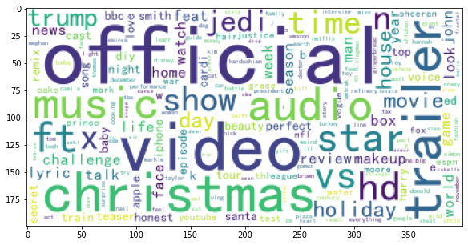

```python
key=[]
for i in range(1,10000):
    key+=word_tokenize(df2['title'][i])
#print(key)

key_words=[]
for i in range(len(key)):
    key_words=key_words+(re.findall('[a-zA-Z]+',key[i]))
#print(key_words)
import nltk

a=[]
for i in range(len(key_words)):
    if( nltk.pos_tag([key_words[i]])[0][1]=="NN"):
        a=a+[key_words[i]]
a = [word for word in a if word not in stopwords.words('english')]

df_all_words=pd.DataFrame(a)
df_all_words.columns=["all_words"]

words_count =df_all_words.groupby('all_words').agg(count=pd.NamedAgg(column='all_words', aggfunc='size')).reset_index().sort_values(
    by='count', ascending=False)

from wordcloud import WordCloud
import matplotlib.pyplot as plt
%matplotlib inline
import matplotlib
matplotlib.rcParams['figure.figsize'] = (10.0, 5.0)

wordcloud=WordCloud(font_path="./data/simhei.ttf",background_color="white",max_font_size=80)
word_frequence = {x[0]:x[1] for x in words_count.values}
wordcloud=wordcloud.fit_words(word_frequence)
plt.imshow(wordcloud)
```

In the overall wordcloud, we can see that the total word count of title are similar to the per month dataframe. There is a similar suggestion that can be given to the youtubers about their tags and topic choice. Youtubers can choose some more popular topics such as iphone or apple watch review, diy project or challanges for their videos. Or they can make vidoes on hoilday events and special topics like new movies. The word they used for title should be attractive to audiences, include words like 'challenge', 'prefect' etc.

## Time-series Analysis

The ARIMA(Auto Regressive Integrated Moving Average) is a widely used statistical method for time-series data forecasting. In this part we are developing an ARIMA model for time series to look at how ‘likes’ is changing over the publish time and to generate a prediction. By doing this, it provides the youtubers probable suggestion on when to publish their video could receive more likes. The model mainly used the algorithm from Python library statsmodels.

```python
dft=df[["publish_time","likes"]]
dft=dft[dft.publish_time>=pd.to_datetime("2017-12-01")]
```

```python
dft1=dft.groupby('publish_time')['likes'].mean()
dft2=dft.groupby('publish_time')['likes'].mean().astype(np.float64).resample('D').mean()
```

Step 1: First look

The data is plotted as a time-series with the month along the x-axis and the likes on the y-axis. Stationarity of series is an important prerequisite for modeling. We can see that the likes has a clear trend and the mean is changing over time so our series is not stationary, which will require differencing to make it stationary.

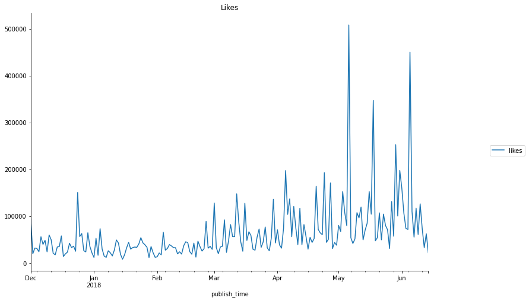

```python
dft2.plot(figsize=(12,8))
plt.legend(bbox_to_anchor=(1.25, 0.5))
plt.title("Likes")
sns.despine()
```

Step 2: First Differences

We then take a first differences of the data and we can now see that the series is stationary. It took one difference to make our series stationary, so we can decide that we have an ARIMA(AR, 1, MA).

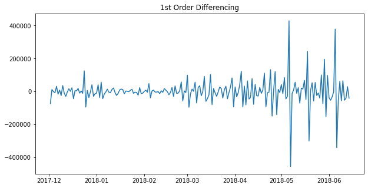

```python
dft3= dft2.diff(1)
plt.figure()
plt.plot(dft3)
plt.title("1st Order Differencing")
plt.show()
```

Step 3: Interpreting ACF(Autocorrelation function) and PACF(Partial Autocorrelation function) plots

Looking at the ACF and PACF function can give us a idea what models to fit. The ACF shows a tapering pattern and has a non-zero values (1) at first and the rest of the values remain close to 0.2 and shows a tapering pattern. PACF has a non-zero values (1) at first and the rest of the values remain close to 0 and shows a tapering pattern. Since the model contains both the AR and MA model, we are able to adjust the parameters and find the ideal one.

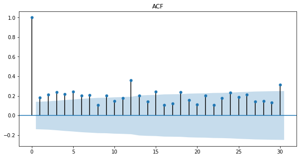

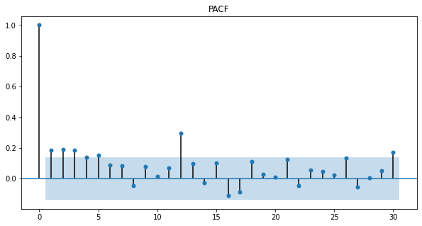

```python
from statsmodels.graphics.tsaplots import plot_acf, plot_pacf
acf = plot_acf(dft2, lags=30)
plt.title("ACF")
acf.show()
pacf = plot_pacf(dft2, lags=30)
plt.title("PACF")
pacf.show()
```

Step 4: ARIMA model

According to the above results, we are using ARIMA(1,1,1) to run the model. The P-value should be less than 0.05 and in our case the p-value is highly insignificant. Therefore our model output is not outstanding enough. The model should get trained multiple times in order to get the optimal ARIMA model, which could be our future goal. For now we are moving to the visualization part.

```python
from statsmodels.tsa.arima_model import ARIMA
model = ARIMA(dft2, order=(1,1,1))
result = model.fit()
print(result.summary())
```

```
                             ARIMA Model Results
==============================================================================
Dep. Variable:                D.likes   No. Observations:                  195
Model:                 ARIMA(1, 1, 1)   Log Likelihood               -2412.364
Method:                       css-mle   S.D. of innovations          56303.159
Date:                Tue, 08 Dec 2020   AIC                           4832.727
Time:                        07:21:19   BIC                           4845.819
Sample:                    12-02-2017   HQIC                          4838.028
                         - 06-14-2018
=================================================================================
                    coef    std err          z      P>|z|      [0.025      0.975]
---------------------------------------------------------------------------------
const           493.0417     69.531      7.091      0.000     356.764     629.319
ar.L1.D.likes    -0.0230      0.072     -0.317      0.751      -0.165       0.119
ma.L1.D.likes    -1.0000        nan        nan        nan         nan         nan
                                    Roots
=============================================================================
                  Real          Imaginary           Modulus         Frequency
-----------------------------------------------------------------------------
AR.1          -43.5242           +0.0000j           43.5242            0.5000
MA.1            1.0000           +0.0000j            1.0000            0.0000
-----------------------------------------------------------------------------
```

```python
pred = result.predict(5,dynamic=True, typ='levels')
print (pred)
```

```
publish_time
2017-12-06     45770.174812
2017-12-07     45773.334447
2017-12-08     46277.631528
2017-12-09     46770.414626
2017-12-10     47263.462265
                  ...
2018-06-10    136997.051142
2018-06-11    137490.092840
2018-06-12    137983.134538
2018-06-13    138476.176235
2018-06-14    138969.217933
Freq: D, Length: 191, dtype: float64
```

Step 5: Visualization and Analysis

The following plot is created showing the predicted values on the original graph. From the perspective of result, this model has better short-term prediction results. Moreover, we can see the predicted values show similar trend and are in the correct scale according to the series. Please also noted the prediction only shows the trend but could not make the conclusion of which month to publish should have the most 'likes'.

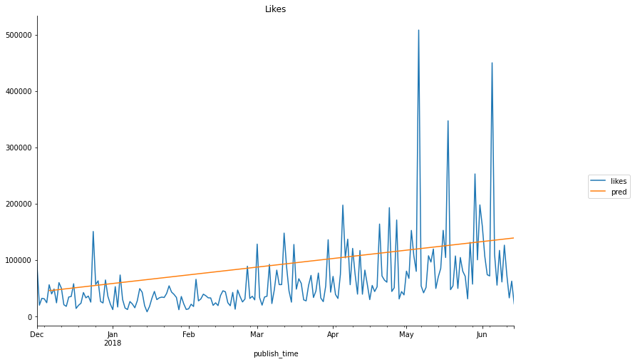

```python
dft2.plot(figsize=(12,8))
pred.plot(figsize=(12,8),label="pred")
plt.legend(bbox_to_anchor=(1.25, 0.5))
plt.title("Likes")
sns.despine()
```

Conclusion

Generally, we designed the project into six analysis: tags and titles analysis, time series analysis, and user interaction analysis. From analyzing the tags, we provide suggestions for youtubers about topic design and content chosen. Similarly, analyzing the title gives youtubers a general idea of how to design the length, keywords and pattern of the video title. We also run a time-series model using ARIMA to look at how ‘likes’ is changing over the publish time. From the above data analysis we can give youtubers suggestions for improving click volume and audience engagement. The three other analysis are included in the user interaction part as shown below.

# User Interaction

User Interaction is a big part of monetizing a youtube channel, so creators are generally very interested in trying to maximize it. In the 3 analyses below we consider which user interactions are most strongly correlated with high performing videos, the expectations for trending youtube videos over time and whether interactions are a necessary condition for trending videos.

## How impactful are user interactions on the success of videos?

```python
rating_int = df2[['video_id','views','likes','dislikes','comment_count', 'rating', 'Impressions', 'Engagement']]
rating_int.corr()
```

|  | views | likes | dislikes | comment_count | rating | Impressions | Engagement |
| --- | --- | --- | --- | --- | --- | --- | --- |
| views | 1.000000 | 0.849177 | 0.472213 | 0.617621 | 0.026428 | 0.999807 | 0.839407 |
| likes | 0.849177 | 1.000000 | 0.447186 | 0.803057 | 0.080572 | 0.858926 | 0.987311 |
| dislikes | 0.472213 | 0.447186 | 1.000000 | 0.700184 | -0.127597 | 0.478471 | 0.572188 |
| comment_count | 0.617621 | 0.803057 | 0.700184 | 1.000000 | -0.011547 | 0.630454 | 0.877075 |
| rating | 0.026428 | 0.080572 | -0.127597 | -0.011547 | 1.000000 | 0.027498 | 0.051937 |
| Impressions | 0.999807 | 0.858926 | 0.478471 | 0.630454 | 0.027498 | 1.000000 | 0.849913 |
| Engagement | 0.839407 | 0.987311 | 0.572188 | 0.877075 | 0.051937 | 0.849913 | 1.000000 |

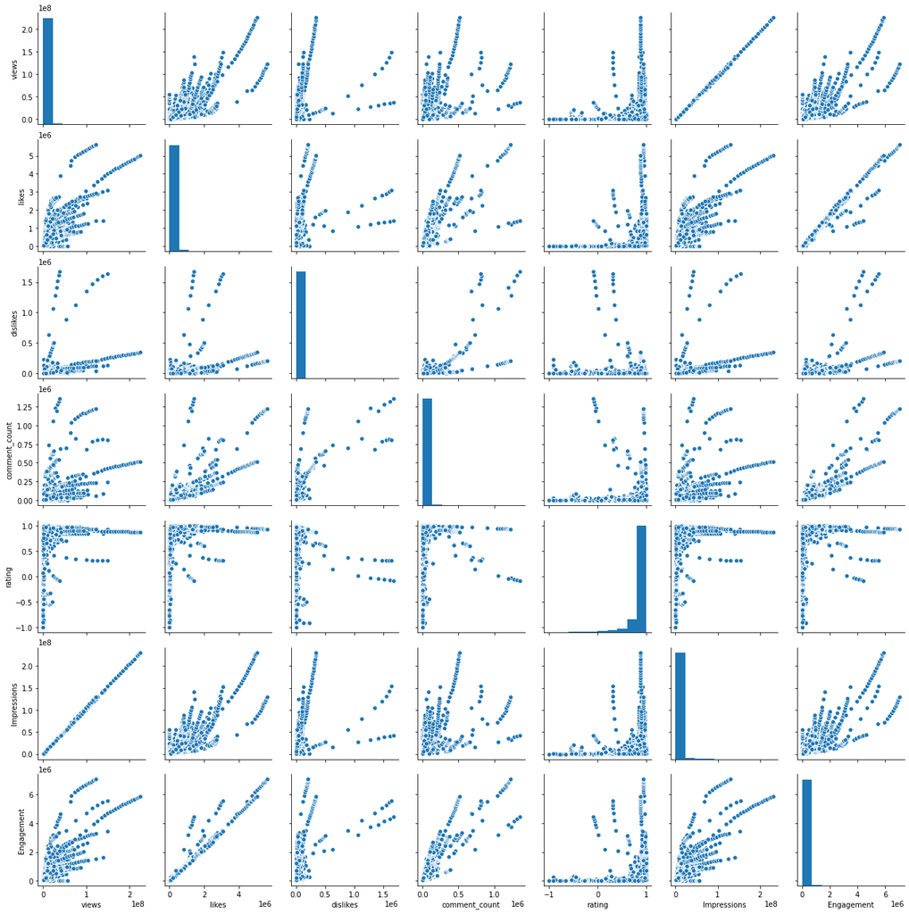

```python
matr = sns.pairplot(rating_int)
```

The scatterplot above is used to visually show the correlation amongst the user interactions and specifically how they correlate with metrics such as impressions and engagement used by YouTube to measure how well a video has done. Overall, based on the scatterplot impressions is highly postively correlated with views as well as likes. While engagement is highly positively correlated with like

We focused on 3 different smaller scatterplots within the larger one that stood out to us as interesting or statistically significant

The graph that shows the correlation between likes and views shows us that there are some videos that get a lot of views per like but after that it models nicely into two different categories of videos with many likes: some videos get tons of views and likes at the same time and some videos get tons of likes but fewer views. This might help us understand the like counter on viral videos.

We then looked at dislikes versus views. Most videos end up acquiring many views without acquiring that many dislikes, having a high ratio of views to dislikes. There are a couple of different possibilities, as in two other tracks the videos can trend in. Widely disliked content seem to follow one of two slopes, as seen from the graph. A content creator could use this graph to track the dislike ratio on their most viewed videos to see which slop pattern it is following. A creator could attempt to predict how many dislikes they're going to get in total throughout the lifespan of the video.

Finally, we loked at the graph describing what the ratio of likes to dislikes is going to be. It doesn't show how big the video is, but rather how well receieved it is. A high dislike to like ratio on videos may get a lot of views, as seen in the scatterplot of views to dislikes where there are two separate slopes that follow such a trend. But if that happens to your videos you may want to consider creating content that is more ad friendly and well received as the youtube algorithm as well as ad sponsors may be hesitant to support controversial creators. To look further into Like ratio and examine this question a little more, we wanted to look at whether or not popular trending videos had a different like to dislike ratio as compared to all other videos on youtube.

```python
#find mean ratio of likes to dislikes for all videos
df['Dislike Ratio'] = df['likes'] / (df['dislikes'] + df['likes'])
mean_ratio = df['Dislike Ratio'].mean()

print(mean_ratio)

#find mean ratio of likes to dislikes for top 100 trending videos of all time
df_top100 = df.sort_values(by=['views'], ascending=False).head(100)
mean_ratio_top100 = df_top100['Dislike Ratio'].mean()

print(mean_ratio_top100)
```

```
0.9331127245054358
0.9315351565603517
```

The mean ratio of likes to dislikes for the top 100 viewed videos is very similar to the mean ratio of likes to dislikes for all videos, refuting the common belief that top videos are overwhelmingly more controversial (or better received) than the average video. As the ratios are very similar it would suggest that very very highly viewed videos are somewhat similar in terms of positive engagement as all other videos on net.

## Which user interaction created the most trending videos?

```python
like_avg = df2.groupby('trending_date')['likes'].mean() #avg likes and other interactions per day
like_avg
dislike_avg = df2.groupby('trending_date')['dislikes'].mean() #avg likes and other interactions per day
dislike_avg
view_avg = df2.groupby('trending_date')['views'].mean() #avg likes and other interactions per day
view_avg
comment_avg = df2.groupby('trending_date')['comment_count'].mean() #avg likes and other interactions per day
comment_avg
rating_avg = df2.groupby('trending_date')['rating'].mean()
rating_avg
dates = df2['trending_date'].unique()
```

[figure not shown]

```python
plt.figure(num = 3, figsize=(10, 7))
plt.plot(dates, like_avg, label='Average Likes', color='orange')
plt.plot(dates, dislike_avg, label='Average Dislikes', color='blue',linestyle='--')
plt.plot(dates, view_avg, label='Average Views', color='red')
plt.plot(dates, comment_avg, label='Average Comments', color='green',linewidth=1.0)
plt.plot(dates, rating_avg, label='Average Rating', color='green',linewidth=1.0)
plt.title('User Interactions Overtime')
plt.xlabel('Date')
plt.ylabel('Interaction Count')
plt.legend(loc="upper left")
plt.show()
```

Based on views consistenly being the highest form of user interaction we make the assumption that this interaction is used as a metric for the algorithm to put videos on the top trending list.

## How does having comments disabled affect the views a video gets? How about having ratings disabled?

The analysis above examines how user interactions affect trending videos. A natural question then is if user interactions themselves are even important to examine. To do this we look at the two videos with limited interaction, comments disabled and ratings disabled videos, and look at whether or not they come out with a lot of views.

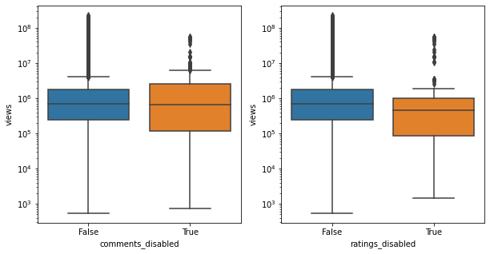

```python
fig, axs = plt.subplots(1, 2)

sns.boxplot(x="comments_disabled", y="views", data=df, ax=axs[0])
#use logscale for y in order to actually be able to see data
axs[0].set_yscale("log")

sns.boxplot(x="ratings_disabled", y="views", data=df, ax=axs[1])
#use logscale for y in order to actually be able to see data
axs[1].set_yscale("log")
```

Videos with comments disabled seem to statistically have very similar view counts as videos with comments enabled. This runs against common sense, which would tell you that disabling commments would give you fewer views but this does not actually seem to be the case. While the interquartile range for videos with comments disabled (True box) is slightly larger than the other, this difference is probably not statistically significant given the difference in sample size. The sample size for comments disabled is obviously much smaller than videos that do not have comments disabled. Therefore any diparity in the box plots is likely just noise and not signal.

# Conclusions

Generally, we designed the project to focus on two aspects within the YouTube platform. One aspect being the youtuber/content creator side and the other being the user side of the platform. For the content creator side we focused our analysis on tags, titles and time series.